# Practical Machine Learning Project

Brian Wang

February 20, 2016

## Goal of this project

The goal of this project is to find the model to predict how well 6 subjects or participants do barbell lifts using data measured by accelerometers on the belt, forearm, arm, and dumbell.

The raw data is provided by Velloso, E.; Bulling, A.; Gellersen, H.; Ugulino, W.; Fuks, H. More information can be found at http://groupware.les.inf.puc-rio.br/har#ixzz4133xZNka.

**1. Load and Preprocess Datasets**

```r
#Load packages and datasets
suppressMessages(library(caret)); suppressMessages(library(ggplot2)); suppressMessages(library(rattle))
suppressMessages(library(rpart)); suppressMessages(library(randomForest))

#Load datasets
trainURL = "https://d396qusza40orc.cloudfront.net/predmachlearn/pml-training.csv"
testURL = "https://d396qusza40orc.cloudfront.net/predmachlearn/pml-testing.csv"
training = read.csv(file = trainURL, header = T, na.strings = c("NA", "", "#DIV/0!"))
testing = read.csv(file = testURL, header = T, na.strings = c("NA", "", "#DIV/0!"))

#Preview the dataset
str(training)
```

```
## 'data.frame':    19622 obs. of  160 variables:
##  $ X                       : int  1 2 3 4 5 6 7 8 9 10 ...
##  $ user_name               : Factor w/ 6 levels "adelmo","carlitos",..: 2 2 2 2 2 2 2 2 2 2 ...
##  $ raw_timestamp_part_1    : int  1323084231 1323084231 1323084231 1323084232 1323084232 1323084232 1323084232 1323084232 1323084232 1323084232 ...
##  $ raw_timestamp_part_2    : int  788290 808298 820366 120339 196328 304277 368296 440390 484323 484434 ...
##  $ cvtd_timestamp          : Factor w/ 20 levels "02/12/2011 13:32",..: 9 9 9 9 9 9 9 9 9 9 ...
##  $ new_window              : Factor w/ 2 levels "no","yes": 1 1 1 1 1 1 1 1 1 1 ...
##  $ num_window              : int  11 11 11 12 12 12 12 12 12 12 ...
##  $ roll_belt               : num  1.41 1.41 1.42 1.48 1.48 1.45 1.42 1.42 1.43 1.45 ...
##  $ pitch_belt              : num  8.07 8.07 8.07 8.05 8.07 8.06 8.09 8.13 8.16 8.17 ...
##  $ yaw_belt                : num  -94.4 -94.4 -94.4 -94.4 -94.4 -94.4 -94.4 -94.4 -94.4 -94.4 ...
##  $ total_accel_belt        : int  3 3 3 3 3 3 3 3 3 3 ...
##  $ kurtosis_roll_belt      : num  NA NA NA NA NA NA NA NA NA NA ...
##  $ kurtosis_picth_belt     : num  NA NA NA NA NA NA NA NA NA NA ...
##  $ kurtosis_yaw_belt       : logi  NA NA NA NA NA NA ...
```

[output cut: 86 more lines]

```r
#Remove variables that has zero variance
newtrain = training[ , -nearZeroVar(training)]

#Remove columns that contain majority of NAs.
index = vector()
for (i in 1:ncol(newtrain)) {
        if (sum(is.na(newtrain[, i])) / nrow(newtrain) > 0.6) {
                index = c(index, i)
        }
}
newtrain = newtrain[, -index]

#Create data petition on training dataset.
set.seed(1)
inTrain = createDataPartition(newtrain$classe, p = 0.7, list = FALSE)
mytrain = newtrain[inTrain, ]
mytest = newtrain[-inTrain, ]
```

**2. Cleaning the Data**

Try to preview some of the variables left to see if they have possible correlation with the outcome. If not, then we could remove those variables in the dataset.

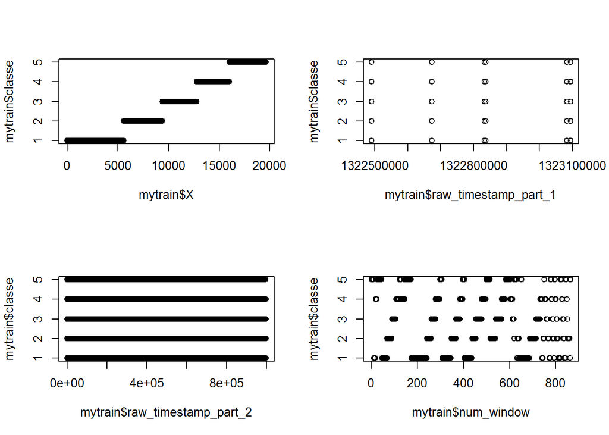

```r
#Exploratory data analysis on some of the variable to verify if they have possible correlation with outcome.
par(mfrow = c(2, 2))
plot(x = mytrain$X, y = mytrain$classe); plot(x = mytrain$raw_timestamp_part_1, y = mytrain$classe)
plot(x = mytrain$raw_timestamp_part_2, y = mytrain$classe); plot(x = mytrain$num_window, y = mytrain$classe)
```

```r
#Remove variables that have no influence on outcome.
mytrain = mytrain[ , -match(c("X", "raw_timestamp_part_1", "raw_timestamp_part_2", "cvtd_timestamp", "num_window"), names(mytrain))]
```

**3. Model Fitting**

*CART*

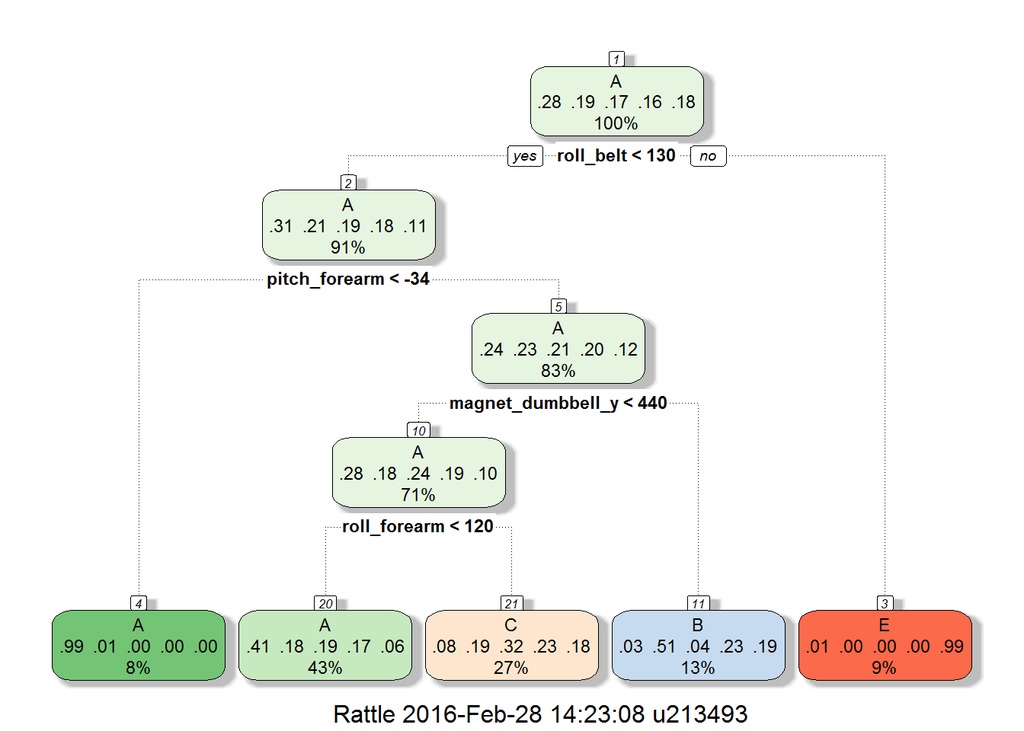

```r
fit = train(classe ~ . , data = mytrain, method = "rpart")
fancyRpartPlot(fit$finalModel)
```

```r
confusionMatrix(mytest$classe, predict(fit, newdata = mytest))
```

```
## Confusion Matrix and Statistics
##
##           Reference
## Prediction    A    B    C    D    E
##          A 1510   27  132    0    5
##          B  463  389  287    0    0
##          C  462   36  528    0    0
##          D  427  163  374    0    0
##          E  179  141  299    0  463
##
## Overall Statistics
##
##                Accuracy : 0.4911
##                  95% CI : (0.4782, 0.5039)
##     No Information Rate : 0.5167
##     P-Value [Acc > NIR] : 1
##
##                   Kappa : 0.3352
##  Mcnemar's Test P-Value : NA
##
## Statistics by Class:
##
##                      Class: A Class: B Class: C Class: D Class: E
## Sensitivity            0.4965   0.5146  0.32593       NA  0.98932
## Specificity            0.9423   0.8538  0.88324   0.8362  0.88573
## Pos Pred Value         0.9020   0.3415  0.51462       NA  0.42791
## Neg Pred Value         0.6364   0.9227  0.77526       NA  0.99896
## Prevalence             0.5167   0.1285  0.27528   0.0000  0.07952
## Detection Rate         0.2566   0.0661  0.08972   0.0000  0.07867
## Detection Prevalence   0.2845   0.1935  0.17434   0.1638  0.18386
## Balanced Accuracy      0.7194   0.6842  0.60458       NA  0.93752
```

*Random Forest*

```r
fit2 = randomForest(classe ~ . , data = mytrain)
confusionMatrix(mytest$classe, predict(fit2, newdata = mytest))
```

```
## Confusion Matrix and Statistics
##
##           Reference
## Prediction    A    B    C    D    E
##          A 1671    2    0    0    1
##          B    2 1136    1    0    0
##          C    0    6 1019    1    0
##          D    0    0    5  958    1
##          E    0    0    0    2 1080
##
## Overall Statistics
##
##                Accuracy : 0.9964
##                  95% CI : (0.9946, 0.9978)
##     No Information Rate : 0.2843
##     P-Value [Acc > NIR] : < 2.2e-16
##
##                   Kappa : 0.9955
##  Mcnemar's Test P-Value : NA
##
## Statistics by Class:
##
##                      Class: A Class: B Class: C Class: D Class: E
## Sensitivity            0.9988   0.9930   0.9941   0.9969   0.9982
## Specificity            0.9993   0.9994   0.9986   0.9988   0.9996
## Pos Pred Value         0.9982   0.9974   0.9932   0.9938   0.9982
## Neg Pred Value         0.9995   0.9983   0.9988   0.9994   0.9996
## Prevalence             0.2843   0.1944   0.1742   0.1633   0.1839
## Detection Rate         0.2839   0.1930   0.1732   0.1628   0.1835
## Detection Prevalence   0.2845   0.1935   0.1743   0.1638   0.1839
## Balanced Accuracy      0.9990   0.9962   0.9964   0.9978   0.9989
```

**4. Predict Testing Dataset**

```r
predict(fit2, newdata = testing)
```

```
##  1  2  3  4  5  6  7  8  9 10 11 12 13 14 15 16 17 18 19 20
##  B  A  B  A  A  E  D  B  A  A  B  C  B  A  E  E  A  B  B  B
## Levels: A B C D E
```